# ChatterBox: Java Messaging Application Project Report

## Project Overview

ChatterBox is a comprehensive peer-to-peer messaging application implemented in Java with a JavaFX user interface. The application provides a rich user experience combining the direct communication benefits of peer-to-peer networking with the connectivity advantages of server-based communication.

The application demonstrates sophisticated Java networking principles by implementing both UDP-based direct messaging and TCP-based server communication within a single coherent user interface. This dual-protocol approach allows users to enjoy the reliability of server-mediated group conversations while also having the option for direct peer connections.

### Key Features

- **User Authentication**: Secure login system with credential validation
- **Direct Messaging**: Person-to-person communication using UDP protocol
- **Group Messaging**: Many-to-many communication via a TCP server
- **File Transfer System**: Reliable chunked file transfer implementation
- **Message Management**: Archiving, deletion, and recovery of messages
- **User Status Tracking**: Real-time status updates (Active, Away, Busy)
- **Logging System**: Comprehensive event logging for diagnostics

The project showcases practical implementation of networking protocols, multi-threading, event-driven programming, and modern UI development with JavaFX.

## Architecture

ChatterBox employs a hybrid architecture that combines:

1. **Peer-to-Peer (P2P) Model**: Direct communication between clients using UDP (User Datagram Protocol)
2. **Client-Server Model**: Centralized communication through a TCP (Transmission Control Protocol) server

This hybrid approach offers several advantages:

- Reduced server load as direct messages bypass the central server
- Continued functionality even when the central server is unavailable
- Scalability through distributed communication channels
- Central point for user discovery and group messaging

### Component Structure

The application is structured around several key components:

- **User Interface Layer**: JavaFX-based UI components managed through FXML
- **Controller Layer**: Mediates between UI and networking components
- **Network Communication Layer**: Handles UDP and TCP protocols
- **File Transfer System**: Manages file transmission and reception
- **Data Management Layer**: Handles message storage and retrieval
- **Logging System**: Provides system-wide logging capabilities

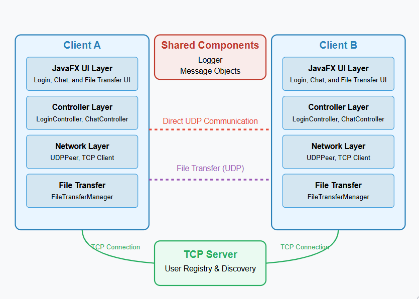

### Communication Flow

When a user sends a direct message:

1. The message is serialized with metadata
2. A UDP datagram is created and sent directly to the recipient
3. The recipient deserializes the message and displays it
4. Acknowledgments are sent back to confirm receipt

For server-based communication:

1. Users connect to the TCP server and register their presence
2. Messages are sent to the server
3. The server broadcasts messages to all connected clients
4. The server maintains a list of active users for discovery

## Core Functionalities

### Login System

ChatterBox features a secure authentication system that verifies user credentials against stored username-password pairs. The system supports both authenticated users and guest access, providing flexibility while maintaining security.

The login process flow:

1. User enters credentials in the login screen
2. The system validates input against stored credentials
3. Upon successful authentication, the user is directed to the main chat interface
4. The username is passed to the chat controller and displayed throughout the session
5. Last login time is recorded and displayed upon subsequent logins

The authentication logic is handled by the `LoginController`:

```java
private void handleLogin(ActionEvent event) {
    String username = usernameField.getText().toLowerCase().strip();
    String password = passwordField.getText();

    if (username.isEmpty() || password.isEmpty()) {
        statusLabel.setText("Please enter username and password");
        return;
    }

    if (credentials.containsKey(username) && credentials.get(username).equals(password)) {
        try {
            FXMLLoader fxmlLoader = new FXMLLoader(App.class.getResource("Chat.fxml"));
            Parent root = fxmlLoader.load();

            ChatController controller = fxmlLoader.getController();
            controller.setUsername(username);

            Scene scene = new Scene(root);
            Stage stage = (Stage) ((Node) event.getSource()).getScene().getWindow();
            stage.setScene(scene);
            stage.setTitle("ChatterBox");
            stage.show();
        } catch (IOException e) {
            statusLabel.setText("Error loading chat screen");
            e.printStackTrace();
        }
    } else {
        statusLabel.setText("Invalid username or password");
    }
}
```

The system maintains login state throughout the session and provides appropriate error messages for authentication failures. The guest login option bypasses credential verification but still maintains username identity for message attribution.

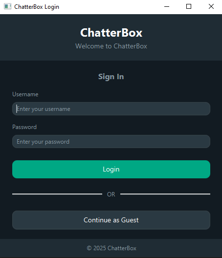

### UDP Messaging

UDP (User Datagram Protocol) forms the backbone of ChatterBox's direct messaging system. This connectionless protocol offers:

- Low overhead communication
- Minimal latency for real-time messaging
- Independence from central server availability

The UDP messaging implementation includes several sophisticated features:

- **Message Formatting**: Each message includes metadata such as sender, timestamp, and a unique message ID
- **Delivery Handling**: Though UDP doesn't guarantee delivery, the application implements application-level acknowledgments
- **Message Display**: Received messages are immediately displayed in the UI with appropriate styling
- **Thread Safety**: All network operations occur on background threads to maintain UI responsiveness

The core of UDP communication is handled by the `UDPPeer` class, which sets up a socket and listens for incoming messages:

```java
public void start() {
    try {
        logger.info("Starting UDPPeer on port " + sourcePort);
        socket = new DatagramSocket(sourcePort);
        running = true;

        this.fileTransferManager = new FileTransferManager(this.socket, this.messageReceiver);

        executorService.submit(new Runnable() {
            @Override
            public void run() {
                listenForMessages();
            }
        });
    } catch (SocketException e) {
        e.printStackTrace();
    }
}

public void sendMessage(String content, String destinationIP, int destinationPort) {
    try {
        String timestamp = LocalDateTime.now().format(formatter);
        String messageId = "Me-" + timestamp.replace(" ", "").replace(":", "");

        // Format: messageId␟username␟content
        String transmissionFormat = messageId + "\u001F" + myUsername + "\u001F" + content;

        byte[] data = transmissionFormat.getBytes();
        InetAddress address = InetAddress.getByName(destinationIP);
        DatagramPacket packet = new DatagramPacket(data, data.length, address, destinationPort);
        logger.info("Sending message to " + destinationIP + ":" + destinationPort + " – content=" + content);
        socket.send(packet);

        Message message = new Message(content, "Me", timestamp, true, messageId);
        messageReceiver.accept(message);
    } catch (IOException e) {
        e.printStackTrace();
    }
}
```

The application handles the complexity of UDP communication by providing clear UI elements for configuring connection parameters and managing socket creation and listening on background threads.

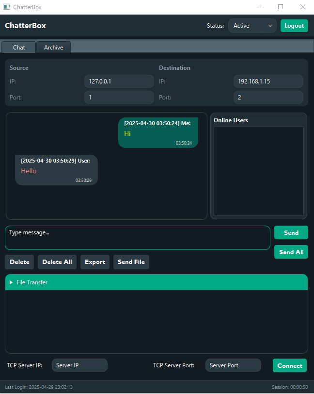

### TCP Server Connection

The TCP server connection enables group communication and user discovery. Unlike UDP's connectionless nature, TCP provides:

- Reliable, connection-oriented communication
- Ordered message delivery
- Built-in flow control

The TCP server component of ChatterBox:

- Maintains a registry of connected users
- Broadcasts messages to all appropriate recipients
- Provides user status updates
- Facilitates user discovery without requiring IP addresses in advance

The server implementation is handled by the `TCPServer` class, which manages client connections and message forwarding:

```java
public void start() {
    running = true;
    executorService.submit(() -> {
        try {
            System.out.println("TCP Server is running and waiting for connections...");
            while (running) {
                Socket socket = tcpSocket.accept();
                handleClient(socket);
            }
        } catch (IOException e) {
            if (running) {
                e.printStackTrace();
            } else {
                System.out.println("TCP Server stopped.");
            }
        }
    });
}

private void forwardMessageToClients(String message, String senderUsername) {
    String[] parts = message.split("\\|");
    String actualMessage = parts.length >= 5 ? parts[4] : message;

    for (String clientInfo : clientsInfo) {
        if (clientInfo.startsWith("CONNECT")) {
            String[] clientParts = clientInfo.split("\\|");

            if (clientParts.length >= 6) {
                String clientIp = clientParts[1];
                try {
                    int udpPort = Integer.parseInt(clientParts[2]);
                    String clientUsername = clientParts[3].split(" ")[0];

                    // Skip forwarding to the sender
                    if (clientUsername.equals(senderUsername) ||
                            clientUsername.startsWith(senderUsername)) {
                        continue;
                    }

                    // Format message with sender information
                    String messageWithSender = senderUsername + "\u001F" + actualMessage;

                    // Send via UDP for efficiency
                    byte[] messageData = messageWithSender.getBytes();
                    InetAddress destAddress = InetAddress.getByName(clientIp);
                    DatagramPacket packet = new DatagramPacket(
                            messageData,
                            messageData.length,
                            destAddress,
                            udpPort
                    );
                    forwardingSocket.send(packet);
                } catch (NumberFormatException | IOException e) {
                    e.printStackTrace();
                }
            }
        }
    }
}
```

This approach combines TCP's reliability for connection management with UDP's efficiency for message delivery.

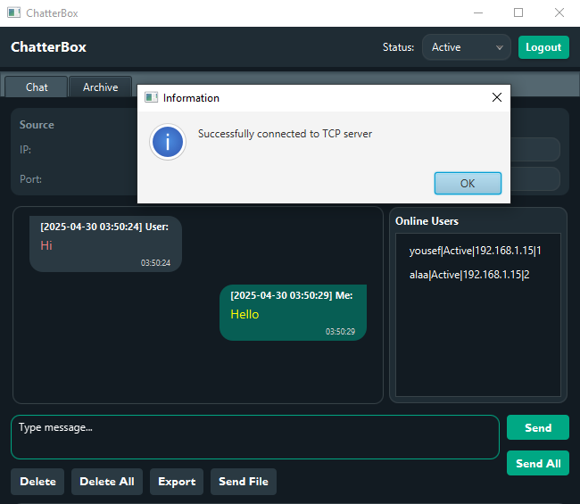

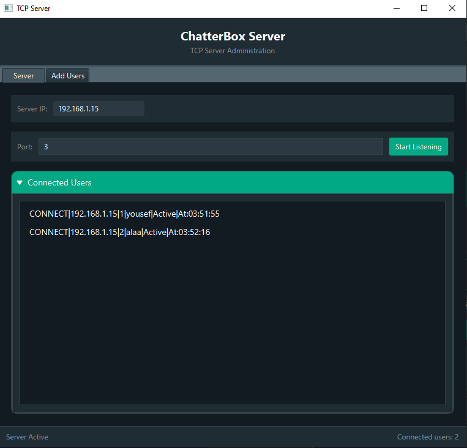

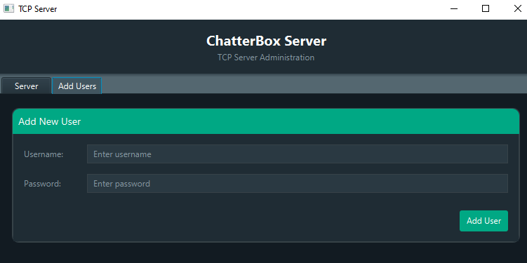

### File Transfer

ChatterBox implements a robust file transfer system capable of reliably transmitting files of various sizes between peers. The system uses a chunked transfer approach to handle large files efficiently and provide progress feedback.

The file transfer system implements several key features:

- **File Chunking**: Large files are broken into manageable chunks for transmission
- **Progress Tracking**: Real-time progress updates are provided to both sender and receiver
- **Transfer Resumption**: Interrupted transfers can potentially be resumed
- **Error Handling**: Comprehensive error detection and reporting
- **Completion Verification**: Verification that all chunks have been received

The file transfer process is managed by the `FileTransferManager` class:

```java
public boolean sendFile(String filePath, String destinationIP, int destinationPort) {
    try {
        File file = new File(filePath);
        if (!file.exists() || !file.isFile()) {
            return false;
        }

        String transferId = UUID.randomUUID().toString();
        logger.info("Initiating file transfer: " + file.getName() + " (" + file.length() +
                    " bytes) to " + destinationIP + ":" + destinationPort);

        // Send file initiation message with metadata
        String initMessage = "CMD:FILE_INIT|" + transferId + "|" + file.getName() + "|" + file.length();
        DatagramPacket packet = new DatagramPacket(
                initMessage.getBytes(),
                initMessage.getBytes().length,
                InetAddress.getByName(destinationIP),
                destinationPort
        );
        socket.send(packet);

        // Store transfer info and start sending chunks in background thread
        FileTransferInfo transferInfo = new FileTransferInfo(file, transferId, destinationIP, destinationPort);
        outgoingTransfers.put(transferId, transferInfo);
        transferInfo.startTime = System.currentTimeMillis();

        new Thread(() -> sendFileChunks(transferInfo)).start();
        return true;
    } catch (IOException e) {
        e.printStackTrace();
        return false;
    }
}
```

The chunking process breaks down large files into manageable pieces, sends them with sequence information, and allows the receiver to reassemble them correctly.

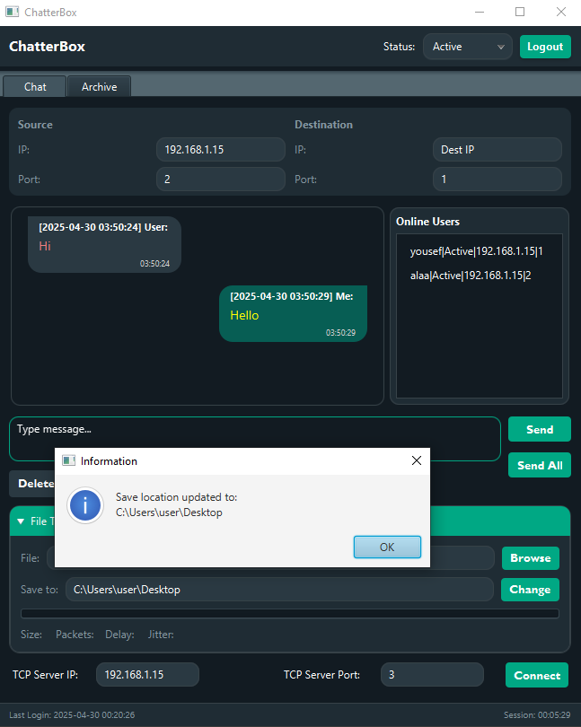

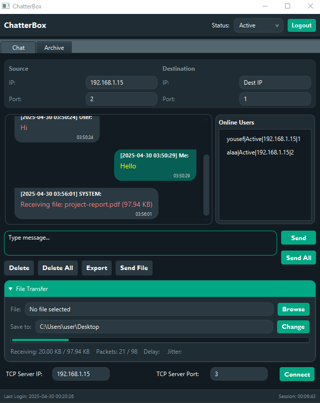

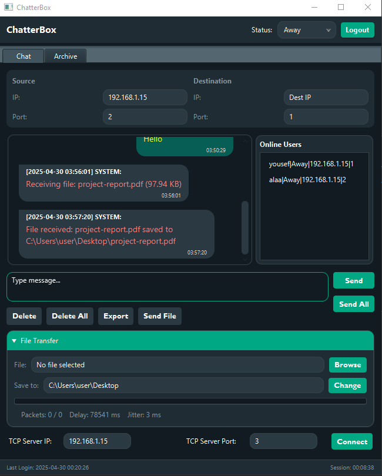

### Message Management

ChatterBox provides comprehensive message management features, allowing users to maintain control over their conversation history. This system treats messages as first-class objects with:

- Unique identifiers for each message
- Metadata including timestamp and sender information
- Status tracking (active, archived, deleted)

The `Message` class encapsulates all necessary metadata:

```java
public static class Message {
    private String content;
    private String sender;
    private String timestamp;
    private boolean sent;
    private String messageId;

    public Message(String content, String sender, String timestamp, boolean sent) {
        this.content = content;
        this.sender = sender;
        this.timestamp = timestamp;
        this.sent = sent;
        this.messageId = sender + "-" + timestamp.replace(" ", "").replace(":", "");
    }

    public Message(String content, String sender, String timestamp, boolean sent, String messageId) {
        this.content = content;
        this.sender = sender;
        this.timestamp = timestamp;
        this.sent = sent;
        this.messageId = messageId;
    }

    // Getters and methods...
}
```

The message archiving system temporarily stores deleted messages for potential recovery:

```java
private void archiveMessage(UDPPeer.Message message) {
    // Create UI representation of archived message
    HBox archiveContainer = new HBox();
    TextFlow textFlow = new TextFlow();
    // ... UI setup code ...

    archivedMessages.add(archiveContainer);
    archiveHistory.add(message);

    // Schedule automatic cleanup after timeout period
    java.util.concurrent.ScheduledFuture<?> cleanupTask = archiveCleanupService.schedule(
        new Runnable() {
            public void run() {
                Platform.runLater(new Runnable() {
                    public void run() {
                        archivedMessages.remove(archiveContainer);
                        archiveHistory.remove(message);
                        cleanupTasks.remove(message.getMessageId());
                    }
                });
            }
        }, 2, TimeUnit.MINUTES);

    cleanupTasks.put(message.getMessageId(), cleanupTask);
}
```

This message management system provides users with complete control over their conversation history while maintaining conversation integrity across all participants.

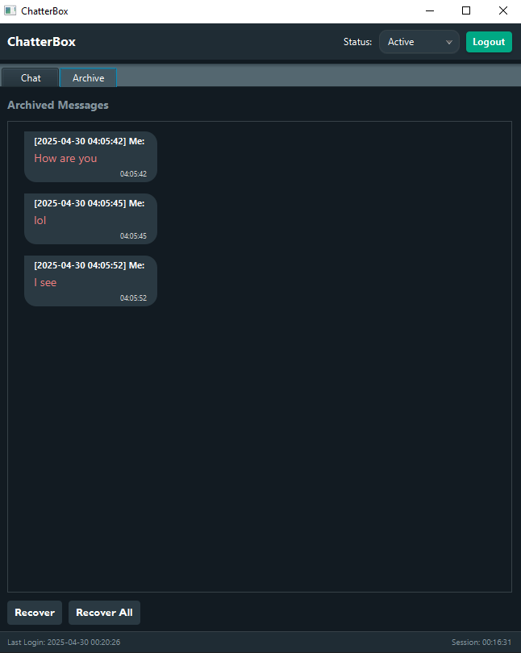

### User Status

The user status system in ChatterBox provides real-time presence information, enhancing the social connectivity of the application. Status information is:

- Displayed prominently in the user interface
- Synchronized across all connected clients
- Updated both manually and automatically

The system supports three distinct status states: Active, Away, and Busy. Status changes are managed through the UI and synchronized over the network:

```java
@FXML
private void handleStatusComboBox() {
    String status = statusComboBox.getValue();
    if (chatClient != null) {
        if (status.equals("Active")) {
            chatClient.setAsActive();
            if (chatClient.getTcpSocket() != null && chatClient.getTcpSocket().isConnected()) {
                chatClient.sendStatusUpdate("Active");
            }
        } else if (status.equals("Away")) {
            chatClient.setAsAway();
            if (chatClient.getTcpSocket() != null && chatClient.getTcpSocket().isConnected()) {
                chatClient.sendStatusUpdate("Away");
            }
        } else if (status.equals("Busy")) {
            chatClient.setAsBusy();
            if (chatClient.getTcpSocket() != null && chatClient.getTcpSocket().isConnected()) {
                chatClient.sendStatusUpdate("Busy");
            }
        }
    }
}
```

The automatic away detection works by monitoring user interaction events:

```java
private void setupInactivityCheck() {
    inactivityTimer = new PauseTransition(Duration.seconds(INACTIVITY_TIMEOUT));
    inactivityTimer.setOnFinished(event -> setStatusAway());
    if (!"Away".equals(statusComboBox.getValue())) {
        chatRoot.addEventFilter(MouseEvent.ANY, this::resetInactivityTimer);
        chatRoot.addEventFilter(KeyEvent.ANY, this::resetInactivityTimer);
    }
}

private void resetInactivityTimer(Event event) {
    inactivityTimer.playFromStart();
    if (!"Busy".equals(statusComboBox.getValue())) {
        setStatusActive();
    }
}
```

This feature enhances the communication experience by setting appropriate expectations about response times and availability.

## JavaFX UI Components

ChatterBox employs JavaFX to create a rich, responsive user interface that integrates all functionality into a coherent user experience. The UI is designed with several key principles:

- Clear visual hierarchy
- Intuitive control placement
- Responsive feedback
- Visual differentiation of message types

### Key UI Components

#### Chat Interface

- Message list with visually distinct sent and received messages
- Text input area with send controls
- User status indicator
- Connection information display
- Archive panel for deleted messages

The logging system provides diagnostic capabilities throughout the application:

```java
public class Logger {
    private static Logger instance;
    private PrintWriter writer;
    private final DateTimeFormatter formatter = DateTimeFormatter.ofPattern("yyyy-MM-dd HH:mm:ss");

    private Logger() {
        try {
            writer = new PrintWriter(new FileWriter("app.log", true), true);
        } catch (IOException e) {
            throw new RuntimeException("Cannot open log file", e);
        }
    }

    public static synchronized Logger getInstance(){
        if(instance == null)
            instance = new Logger();
        return instance;
    }

    public synchronized void log(String level, String msg){
        String timeStamp = LocalDateTime.now().format(formatter);
        writer.printf("%s [%s] %s%n", timeStamp, level, msg);
    }

    public void info(String msg)  { log("INFO",  msg); }
    public void warn(String msg)  { log("WARN",  msg); }
    public void error(String msg) { log("ERROR", msg); }
}
```

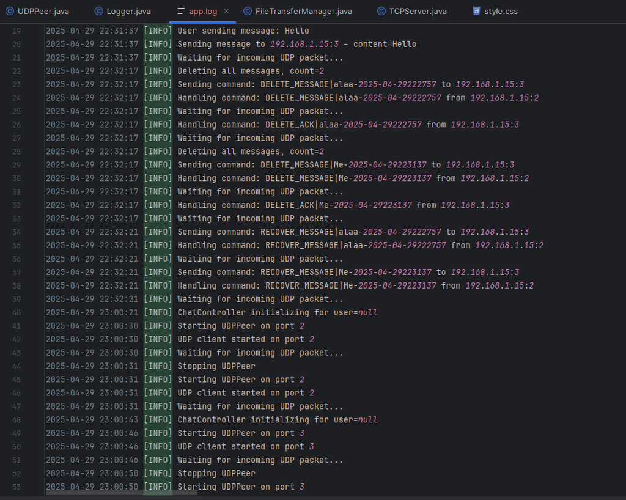

```java
private void sendDeleteAcknowledgment(String messageId, String destIp, int destPort) {
    try {
        String ackCommand = "CMD:DELETE_ACK|" + messageId;
        DatagramPacket packet = new DatagramPacket(
                ackCommand.getBytes(),
                ackCommand.getBytes().length,
                InetAddress.getByName(destIp),
                destPort
        );
        socket.send(packet);
    } catch (IOException e) {
        e.printStackTrace();
    }
}
```

## Conclusion

ChatterBox represents an implementation of modern networking principles within a user-friendly Java application. By combining UDP and TCP protocols, the application demonstrates:

1. **Protocol Complementarity**: How different network protocols can complement each other in a single application
2. **Layered Architecture**: Clear separation of UI, business logic, and network communication
3. **Event-Driven Programming**: Responsive design that handles asynchronous events gracefully
4. **User-Centered Design**: Technical complexity hidden behind intuitive interfaces

The application showcases several advanced Java concepts:

- Socket programming with both UDP and TCP
- Multi-threaded application design
- JavaFX UI development
- Event handling and propagation
- File operations and streaming

As a learning tool, ChatterBox demonstrates how theoretical networking concepts translate into practical implementations with real-world considerations like error handling, user experience, and performance optimization.